# Week-4 Functions

## Functions

A function, in a programming environment, is a set of instructions. A developer or programmer for analytics builds a function to avoid repeating the same task, or reduce complexity.

A function draws on black box principle where there is an input >>> goes into a box >> and generates output

A function should be

1. Written to carry out a specified a tasks
2. May or may not include arguments
3. Contain a body
4. May or may not return one or more values.

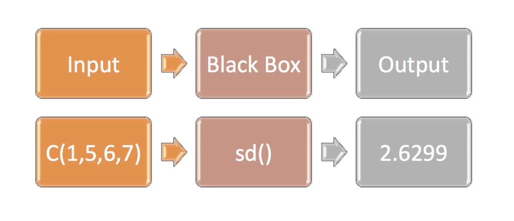

Functions

A general approach to a function is to use the argument part as inputs, feed the body part and finally return an output. The Syntax of a function is the following:

```r
function (arglist)  {
  #Function body
}
```

```r
sd(c(1,5,6,7))
```

```
## [1] 2.629956
```

```r
value<-c(1,5,6,7)
sd(value)
```

```
## [1] 2.629956
```

```r
my_own_sd<-sd(value)
my_own_sd
```

```
## [1] 2.629956
```

```r
help(sd)
?sd
```

```r
#Arguement Matching
sd(x,na.rm=FALSE)
# By Position
sd(value)
# By Name
sd(x=value)
```

na.rm: Logical. Should I remove missing values?

```r
value<-c(1,5,6,NA)
sd(value)
```

```
## [1] NA
```

```r
sd(value, TRUE) #Matching by position
```

```
## [1] 2.645751
```

```r
#by position  by name
sd(value, na.rm=TRUE)
```

```
## [1] 2.645751
```

```r
value<-c(1,5,6,7)
sd(value)
```

```
## [1] 2.629956
```

```r
args(sd)
```

```
## function (x, na.rm = FALSE)
## NULL
```

#### Summary

Functions work like a black box

Argument matching: by position or by name

Function arguments can have defaults

### How/When to Write Functions?

Solve a particular, well-defined problem

Black box principle

If it works, inner workings less important

input >> triple() >> output

```r
myfunction<-function(arg1, arg2){
  body
}
```

```r
myfunction<-function(x){
  3*x
}
```

```r
triple<-function(x){
  3*x
}
```

```r
triple(6)
```

```
## [1] 18
```

Numeric 6 matched to argument x (by pos)

Function body is executed: 3 * 6

Last expression = return value

#### return()

```r
triple<-function(x){
  y<-3*x
  return(y)
}
```

```r
triple(6)
```

```
## [1] 18
```

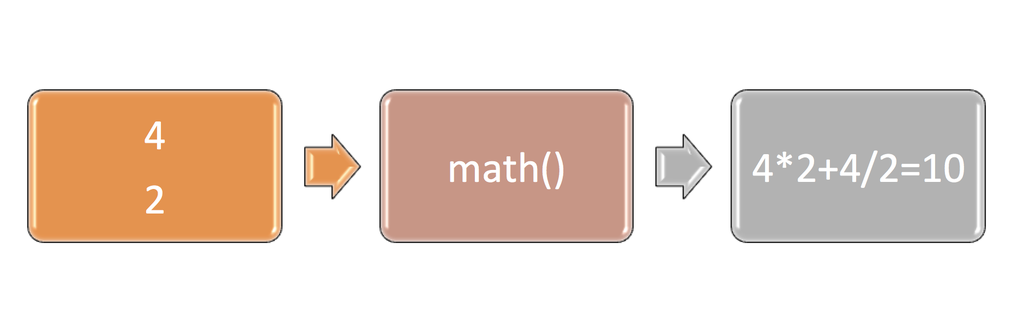

Importance of Return() with math function

```r
mathh<-function(a,b){
  a*b + a/b
}
```

```r
mathh(4,2)
```

```
## [1] 10
```

```r
mathh(4)
```

Optional Argument

```r
math_opt<-function(a, b=1){
  a*b + a/b
}
```

```r
math_opt(4)
```

```
## [1] 8
```

```r
math_opt(4,0)
```

```
## [1] Inf
```

Use return()

```r
math_return <- function(a, b = 1) {
  if(b==0){
    return(0)  #return 0 and exit function
  }
 a*b + a/b  #not reached if b is 0
}
```

```r
math_return(4,0)
```

```
## [1] 0
```

### Practice

Consult the documentation on the mean() function

Inspect the arguments of the mean() function

Q1. Calculate the average number of views for both linkedin and instagram and assign the result to avg_li and avg_ins, respectively.

use these vectors again:

linkedin <- c(16, 9, 13, 5, 2, 17, 14)

instagram<- c(17, 7, 5, 16, 8, 13, 14)

Q2.Calculate the means of the element-wise sum of linkedin and instagram and stor ethe result in a variable avg_sum. Calculate the mean once again but use trim=0.2 this time and assign the result to avg_sum_trimmed. Print both.

Hint: mean(x, trim = 0, na.rm = FALSE, …) ellipsis construct issue which will be covered later.

trim: the fraction (0 to 0.5) of observations to be trimmed from each end of x before the mean is computed. Values of trim outside that range are taken as the nearest endpoint.

Q3. linkedin <- c(16, 9, 13, 5, NA, 17, 14)

instagram <- c(17, NA, 5, 16, 8, 13, 14)

Print Basic average of linkedin

Print Advanced average of linkedin

Print whether th elements of linkedin have a match in instagram

Q4. Calculate the mean absolute deviation of linkedin from instagram

linkedin <- c(16, 9, 13, 5, NA, 17, 14)

instagram <- c(17, NA, 5, 16, 8, 13, 14)

Hint. abs(linkedin-instagram)>>absolute deviation

Q5.Create a function power_two(): it takes one argument and returns that number squared (that number times itself).Call this newly defined function with 12 as input.Next, create a function sum_absol(), that takes two arguments and returns the sum of the absolute values of both arguments.Finally, call the function sum_absol() with arguments -2 and 3 afterwards.

#### Function Scoping

Function scoping implies that variables that are defined inside a function are not accessible outside that function.

```r
power_two <- function(x) {
  y <- x ^ 2
  return(y)
}
power_two(4)
y
x
```

y was defined inside the power_two() function and therefore it is not accessible outside of that function. This is also true for the function’s arguments of course - x in this case.